# Set_12

Alexander Williams

2024-10-22

# Polynomial Regression

a generalization from the linear model

## Example: Radioactive emissions

relation between time (x) and emissions (y)

```r
curve<-read.table(file ='~/Documents/uni/STAT359/data/decay.txt',header=TRUE,sep="")
attach(curve)
names(curve)
```

```
## [1] "x" "y"
```

```r
summary(curve)
```

```
##        x              y
##  Min.   : 0.0   Min.   :  8.196
##  1st Qu.: 7.5   1st Qu.: 21.522
##  Median :15.0   Median : 35.015
##  Mean   :15.0   Mean   : 42.146
##  3rd Qu.:22.5   3rd Qu.: 57.460
##  Max.   :30.0   Max.   :125.000
```

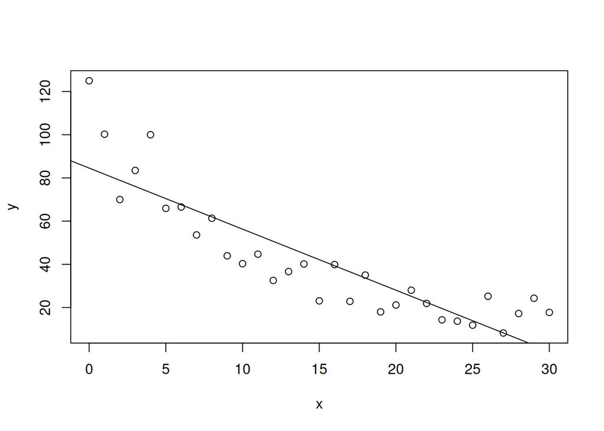

```r
plot(x,y)
abline(lm(y~x))
```

```r
summary(lm(y~x))
```

```
##
## Call:
## lm(formula = y ~ x)
##
## Residuals:
##     Min      1Q  Median      3Q     Max
## -19.065 -10.029  -2.058   5.107  40.447
##
## Coefficients:
##             Estimate Std. Error t value Pr(>|t|)
## (Intercept)  84.5534     5.0277   16.82  < 2e-16 ***
## x            -2.8272     0.2879   -9.82 9.94e-11 ***
## ---
## Signif. codes:  0 '***' 0.001 '**' 0.01 '*' 0.05 '.' 0.1 ' ' 1
##
## Residual standard error: 14.34 on 29 degrees of freedom
## Multiple R-squared:  0.7688, Adjusted R-squared:  0.7608
## F-statistic: 96.44 on 1 and 29 DF,  p-value: 9.939e-11
```

$r^2=0.7688$, which is a bit low. We can try to improve this by adding a non-linear term.

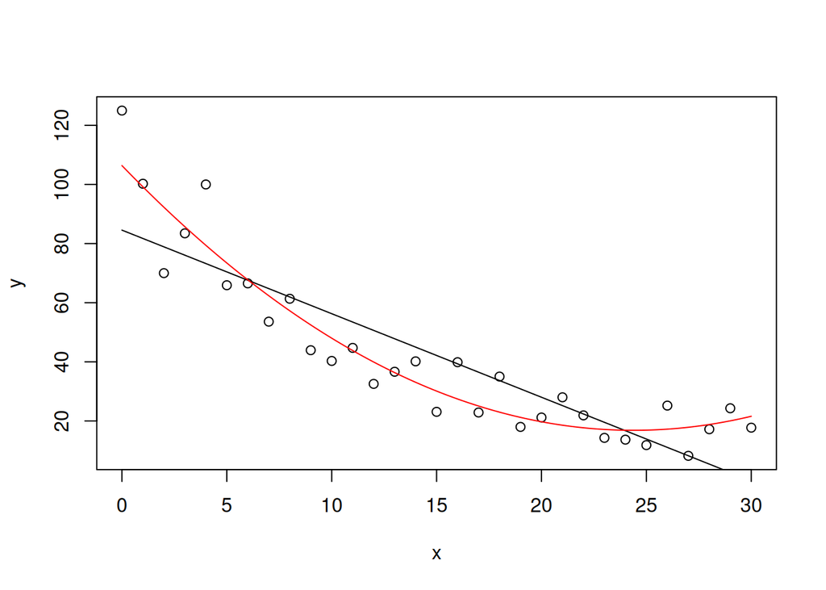

```r
x2<-x^2
quadratic<-lm(y~x+x2)

plot(x,y)
xv<-seq(0,30,.1)
## plot the line
linear<-lm(y~x)
yv.linear<-predict(linear,list(x=xv))
lines(xv,yv.linear)
## plot the quadratic model
yv.quadratic<-predict(quadratic,list(x=xv,x2=xv^2))
lines(xv,yv.quadratic,col="red")
```

```r
summary(quadratic)
```

```
##
## Call:
## lm(formula = y ~ x + x2)
##
## Residuals:
##     Min      1Q  Median      3Q     Max
## -22.302  -6.044  -1.603   4.224  20.581
##
## Coefficients:
##              Estimate Std. Error t value Pr(>|t|)
## (Intercept) 106.38880    4.65627  22.849  < 2e-16 ***
## x            -7.34485    0.71844 -10.223 5.90e-11 ***
## x2            0.15059    0.02314   6.507 4.73e-07 ***
## ---
## Signif. codes:  0 '***' 0.001 '**' 0.01 '*' 0.05 '.' 0.1 ' ' 1
##
## Residual standard error: 9.205 on 28 degrees of freedom
## Multiple R-squared:  0.908,  Adjusted R-squared:  0.9014
## F-statistic: 138.1 on 2 and 28 DF,  p-value: 3.122e-15
```

$r^2$ went up to 0.9, that’s a large improvement. the p-values are also very small, so we have evidence that time does effect radioactive emissions.

lets compare the two models with anova

```r
anova(quadratic,linear)
```

```
## Analysis of Variance Table
##
## Model 1: y ~ x + x2
## Model 2: y ~ x
##   Res.Df    RSS Df Sum of Sq      F    Pr(>F)
## 1     28 2372.6
## 2     29 5960.6 -1   -3588.1 42.344 4.727e-07 ***
## ---
## Signif. codes:  0 '***' 0.001 '**' 0.01 '*' 0.05 '.' 0.1 ' ' 1
```

we can also use anova to compare multiple models at once

```r
## compare a sequence of four nested models
constant<-lm(y~1)
linear<-lm(y~x)
x3<-x^3
cubic<-lm(y~x+x2+x3)
## compare 4 nested models
## the F-statistic provides pairwise comparison of models
## numerator = difference in RSS/difference in DF
## denominator = RSS of largest model/DF
anova(constant,linear,quadratic,cubic)
```

```
## Analysis of Variance Table
##
## Model 1: y ~ 1
## Model 2: y ~ x
## Model 3: y ~ x + x2
## Model 4: y ~ x + x2 + x3
##   Res.Df     RSS Df Sum of Sq        F    Pr(>F)
## 1     30 25783.1
## 2     29  5960.6  1   19822.5 244.1646 4.766e-15 ***
## 3     28  2372.6  1    3588.1  44.1961 3.911e-07 ***
## 4     27  2192.0  1     180.6   2.2246    0.1474
## ---
## Signif. codes:  0 '***' 0.001 '**' 0.01 '*' 0.05 '.' 0.1 ' ' 1
```

Anova compares in sequence, only compares each model to the one next to it.

model one is constant, not very good.

model 2 compared to model one, the linear model 2 is better.

model 3 is compared to model 2, the quadratic model is better.

model 4 is compared to model 3, and the p-value is high. quadratic is still better

The quadratic model is the best of all, there’s no evidence to reject it over the cubic model.

Lets graph these models

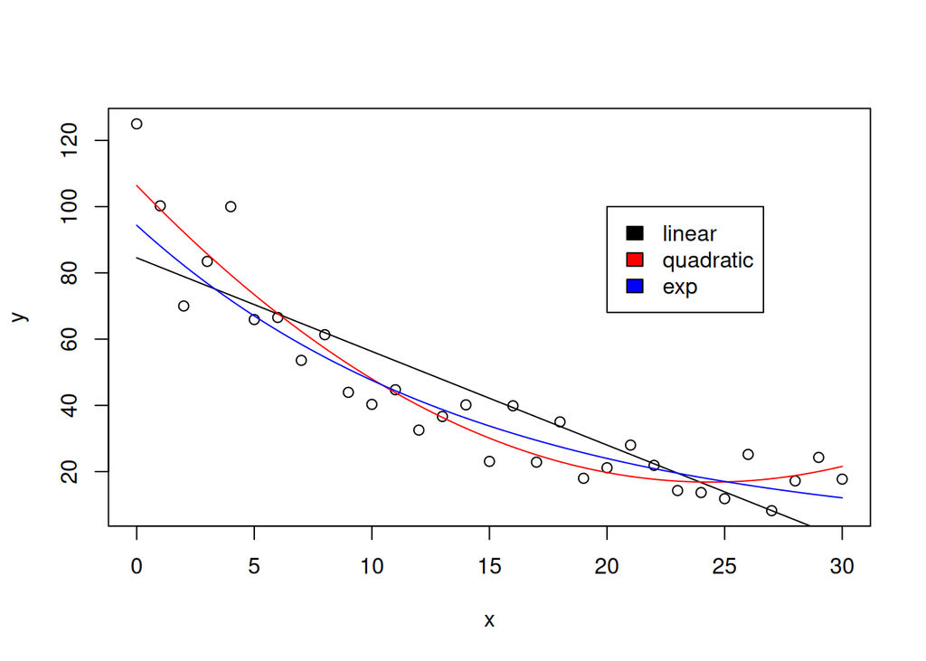

```r
plot(x,y)
xv<-seq(0,30,.1) #xv is sample data just used to visualize the line
## plot the line
linear<-lm(y~x)
yv.linear<-predict(linear,list(x=xv))
lines(xv,yv.linear)
## plot the quadratic model
yv.quadratic<-predict(quadratic,list(x=xv,x2=xv^2))
lines(xv,yv.quadratic,col="red")

exponential<-lm(log(y)~x)
## make predictions on the log scale and exponentiate
yv.exp<-exp(predict(exponential,list(x=xv)))
lines(xv,yv.exp,col="blue")

legend(x=20,y=100,legend=c("linear","quadratic","exp"),fill=c("black","red","blue"))
```

One concern with the quadratic model is that it’s going up near the end of the datapoints. We know for this case that radiation doesn’t increase over time, so this is due to noise. How can we prevent this and make the line more accurate to the science of decay?

That’s what the exponential model is for, it might fit the data better. We’re just fitting a linear model to the log of y

```r
summary(exponential)
```

```
##
## Call:
## lm(formula = log(y) ~ x)
##
## Residuals:
##     Min      1Q  Median      3Q     Max
## -0.5935 -0.2043  0.0067  0.2198  0.6297
##
## Coefficients:
##              Estimate Std. Error t value Pr(>|t|)
## (Intercept)  4.547386   0.100295   45.34  < 2e-16 ***
## x           -0.068528   0.005743  -11.93 1.04e-12 ***
## ---
## Signif. codes:  0 '***' 0.001 '**' 0.01 '*' 0.05 '.' 0.1 ' ' 1
##
## Residual standard error: 0.286 on 29 degrees of freedom
## Multiple R-squared:  0.8308, Adjusted R-squared:  0.825
## F-statistic: 142.4 on 1 and 29 DF,  p-value: 1.038e-12
```

Notice that the $r^2$ went down, the exponential model accounts for less variability than the quadratic model. We might be willing to accept this because we know this data is from exponential decay, or we might say it’s hard to compare the $r^2$ values since this model was trained on $log(y)$ instead of $y$.